# **STACK**

Struktur Data Struktur data merupakan cara programmer untuk merepresentasikan suatu data, dan memudahkan programmer untuk menyelesaikan permasalahan dengan menggunakan struktur data tersebut.

Struktur data **Linear Structure** merupakan struktur data sederhana dimana ketika data ditambahkan maka data tersebut berada pada posisi relatif terhadap data yang lain dari struktur data tersebut. Linear structure ini memiliki dua buah ujung. Dua buah ujung ini memiliki beberapa istilah seperti **left-right**, **front-rear**, ataupun **top-bottom**. Terdapat beberapa struktur data yang termasuk pada linear structure ini, yaitu :

- Stacks
- Queues
- Lists

Ketiga jenis struktur data tersebut berbeda dalam penambahan atau penghapusan suatu data. Misalkan, suatu struktur data hanya diperbolehkan menghapus data pada salah satu ujung, sedangkan pada struktur data lain, penghapusan data dapat dilakukan pada kedua ujung.

Struktur data yang akan dibahas pertama kali adalah Stacks, yang terdiri dari :

1. Stacks
2. Operasi Stacks
3. Contoh Implementasi Stacks
4. Ekspressi Aritmatik Infix, Prefix, Postfix

## **Definisi Stacks**

**Stacks** adalah satu struktur data dimana penambahan dan penghapusan data, hanya dapat dilakukan pada satu ujung yang sama, atau yang biasa dikenal dengan istilah **top.**

Semakin data jauh berada dari posisi top, maka data tersebut diindikasikan berada di stack lebih lama dibandingkan dengan data yang berada dekat pada data di posisi top.

Jika terdapat data baru yang ditambahkan di stack, maka data ini pulalah yang akan dihapus ketika terdapat proses penghapusan data. Konsep ini dikenal dengan nama **LIFO-Last In First Out.**

## **Operasi pada Stacks**

Terdapat operasi dasar pada Stacks,

- stack (), inisialisasi stack yang kosong
- push(data), penambahan data baru pada posisi top dari stack
- pop(), penghapusan data yang terdapat di posisi top dari stack. R eturn value dari fungsi ini adalah data yang dihapus dari stack tersebut
- peek(), informasi data yang terletak pada posisi top
- isEmpty(), untuk memeriksa apakah stack dalam keadaan kosong
- size(), informasi jumlah data yang terdapat pada stack

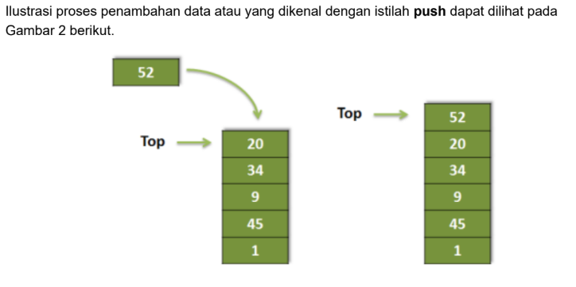

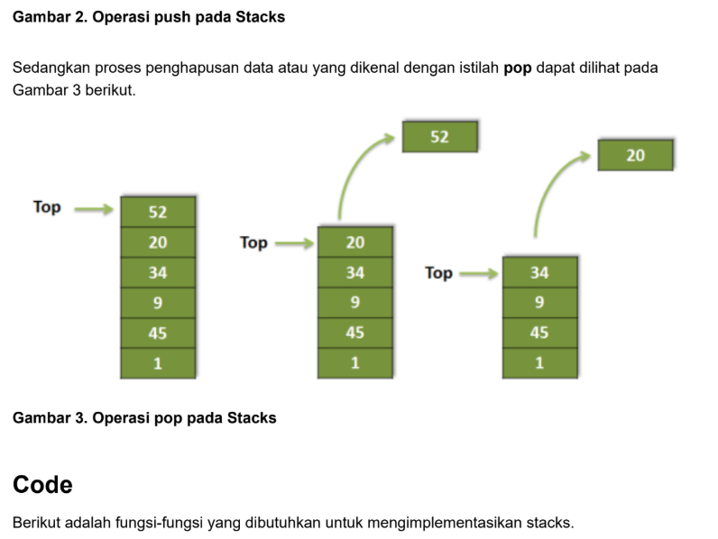

```python
def stack():
s=[]
return (s)
def push(s,data):
s.append(data)
def pop(s):
data=s.pop()
return(data)
def peek(s):
return(s[len(s)-1])
def isEmpty(s):
return (s==[])
def size(s):
return(len(s))
```

[output not shown]

Struktur data direpresentasikan dengan lists. Posisi top dari suatu stacks berada pada posisi terakhir pada list, oleh karena itu, operasi push pada stack, menggunakan method append dari list, sehingga dengan operasi append ini, penambahan data baru terletak pada posisi akhir pada list.

Sedangkan operasi pop pada list, menggunakan method pop dari list, karena method pop ini menghapus data yang terletak pada posisi akhir dari list.

```python
#Berikut adalah contoh penggunaan fungsi-fungsi stacks yang telah dibuat

import Stack as st

data=st.stack()
st.isEmpty(data)

st.push(data,100)
st.push(data,23)
st.push(data,34)
st.pop(data)
st.push(data,56)
st.pop(data)
print(data)
```

[output not shown]